# Ordinal treatment effect of mechanical thrombectomy

Author

Bradley Kolb

Comprehensive evaluation of randomized evidence for mechanical thrombectomy using bayesian implementation of random effects meta-analysis with ordinal data in `stan` using `brms`.

# Dependencies

```r
suppressMessages({
  library(tidyverse)
  library(brms)
  library(posterior)
  library(here)
  library(tinytable)
})
```

# Data

```r
all_dat <- readRDS("all_dat.rds")
```

## Data description

Table 1 shows the data from the 22 randomized trials of thrombectomy. Trials are categorized by type of stroke treated.

Table 1: Ordinal outcomes from 22 thrombectomy RCTs

| type | trial | treatment | mRS at six months zero | mRS at six months one | mRS at six months two | mRS at six months three | mRS at six months four | mRS at six months five | mRS at six months six |
| --- | --- | --- | --- | --- | --- | --- | --- | --- | --- |
| large | angel | thrombectomy | 9 | 19 | 41 | 39 | 45 | 27 | 50 |
| large | angel | medical | 0 | 8 | 18 | 49 | 60 | 45 | 45 |
| large | rescue | thrombectomy | 2 | 3 | 9 | 17 | 33 | 18 | 18 |
| large | rescue | medical | 0 | 3 | 5 | 5 | 25 | 40 | 24 |
| large | select | thrombectomy | 2 | 9 | 25 | 31 | 27 | 15 | 68 |
| large | select | medical | 0 | 3 | 9 | 20 | 36 | 32 | 71 |
| large | tension | thrombectomy | 5 | 5 | 11 | 18 | 24 | 15 | 46 |
| large | tension | medical | 1 | 1 | 1 | 13 | 16 | 24 | 66 |
| large | tesla | thrombectomy | 6 | 8 | 8 | 23 | 30 | 23 | 53 |
| large | tesla | medical | 2 | 6 | 5 | 16 | 35 | 33 | 49 |
| early | escape | thrombectomy | 25 | 34 | 30 | 26 | 21 | 11 | 16 |
| early | escape | medical | 10 | 15 | 18 | 22 | 35 | 18 | 28 |
| early | extend | thrombectomy | 9 | 9 | 7 | 6 | 1 | 0 | 3 |
| early | extend | medical | 6 | 4 | 4 | 4 | 6 | 4 | 7 |
| early | mrclean | thrombectomy | 7 | 21 | 49 | 42 | 51 | 14 | 49 |
| early | mrclean | medical | 1 | 16 | 35 | 43 | 80 | 32 | 59 |
| early | piste | thrombectomy | 5 | 9 | 3 | 4 | 4 | 1 | 7 |
| early | piste | medical | 1 | 5 | 6 | 7 | 4 | 3 | 4 |
| early | resilient | thrombectomy | 9 | 13 | 17 | 24 | 14 | 7 | 27 |
| early | resilient | medical | 3 | 7 | 13 | 17 | 21 | 18 | 33 |
| early | revascat | thrombectomy | 7 | 18 | 20 | 19 | 8 | 12 | 19 |
| early | revascat | medical | 6 | 7 | 16 | 20 | 17 | 21 | 16 |
| early | swift | thrombectomy | 17 | 25 | 17 | 12 | 15 | 3 | 9 |
| early | swift | medical | 8 | 10 | 15 | 16 | 20 | 12 | 12 |
| early | therapy | thrombectomy | 3 | 10 | 6 | 8 | 15 | 2 | 6 |
| early | therapy | medical | 1 | 6 | 7 | 7 | 10 | 4 | 11 |
| early | thrace | thrombectomy | 31 | 39 | 36 | 25 | 34 | 11 | 24 |
| early | thrace | medical | 24 | 33 | 28 | 25 | 56 | 9 | 27 |
| late | dawn | thrombectomy | 10 | 24 | 18 | 14 | 14 | 8 | 20 |
| late | dawn | medical | 4 | 5 | 4 | 16 | 34 | 19 | 18 |
| late | defuse3 | thrombectomy | 9 | 15 | 17 | 14 | 17 | 7 | 13 |
| late | defuse3 | medical | 7 | 4 | 4 | 14 | 24 | 14 | 23 |
| late | mrcleanlate | thrombectomy | 23 | 31 | 46 | 28 | 31 | 33 | 61 |
| late | mrcleanlate | medical | 5 | 35 | 44 | 20 | 27 | 42 | 74 |
| late | positive | thrombectomy | 4 | 4 | 1 | 0 | 1 | 1 | 1 |
| late | positive | medical | 1 | 3 | 5 | 3 | 2 | 3 | 4 |
| basilar | attention | thrombectomy | 11 | 34 | 29 | 29 | 11 | 27 | 84 |
| basilar | attention | medical | 5 | 5 | 3 | 14 | 6 | 19 | 63 |
| basilar | baoche | thrombectomy | 7 | 20 | 17 | 8 | 10 | 15 | 34 |
| basilar | baoche | medical | 1 | 6 | 7 | 11 | 20 | 16 | 45 |
| basilar | basics | thrombectomy | 8 | 19 | 27 | 14 | 10 | 17 | 59 |
| basilar | basics | medical | 6 | 13 | 25 | 11 | 16 | 12 | 63 |
| basilar | best | thrombectomy | 4 | 11 | 7 | 6 | 5 | 11 | 22 |
| basilar | best | medical | 6 | 10 | 2 | 3 | 12 | 7 | 25 |

“Large” refers to anterior circulation strokes with a large infarct core. “Early” refers to anterior circulation strokes with a small core, treated in an early time window. “Late” refers to anterior circulation strokes with a small core, treated in an extended time window. “Basilar” refers to posterior circulation strokes due to vertebro-basilar occlusion.

## Data exploration

Figure 1 plots the data from Table 1.

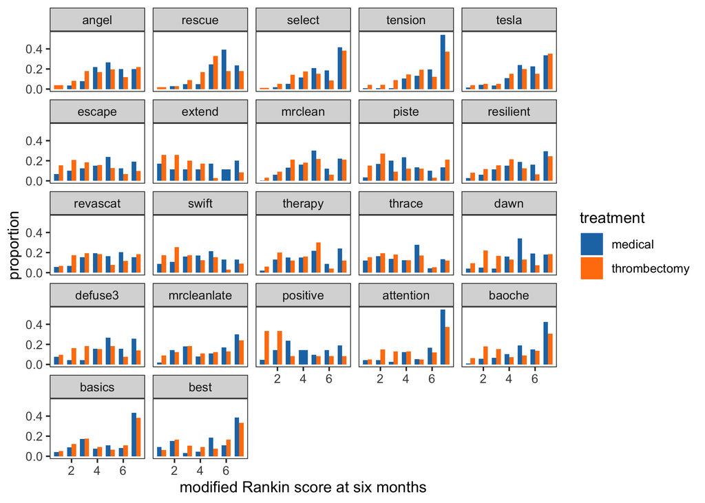

Figure 1: Distribution of ordinal values by treatment group for all thrombectomy RCTs

# Model

## Model description

We use `brms` to define and fit an ordinal meta-regression in the probabilistic programming language `stan`. Specifically, we use an adjacent category ordinal regression with category specific treatment effects, correlated trial-specific varying intercepts and slopes, and a predictor term for stroke type.

## Model summary

Summary of the model is shown as follows.

```
 Family: acat
  Links: mu = logit; disc = identity
Formula: ordinal_value ~ type + cs(treatment) + (1 + treatment | trial)
   Data: all_dat_long (Number of observations: 5518)
  Draws: 4 chains, each with iter = 2000; warmup = 1000; thin = 1;
         total post-warmup draws = 4000

Group-Level Effects:
~trial (Number of levels: 22)
                                     Estimate Est.Error l-95% CI u-95% CI Rhat
sd(Intercept)                            0.13      0.03     0.08     0.19 1.00
sd(treatmentthrombectomy)                0.08      0.03     0.02     0.14 1.01
cor(Intercept,treatmentthrombectomy)    -0.40      0.30    -0.84     0.30 1.00
                                     Bulk_ESS Tail_ESS
sd(Intercept)                            1595     2567
sd(treatmentthrombectomy)                1104     1101
cor(Intercept,treatmentthrombectomy)     2090     2114

Population-Level Effects:
                         Estimate Est.Error l-95% CI u-95% CI Rhat Bulk_ESS
Intercept[1]                -1.04      0.13    -1.30    -0.78 1.00     2100
Intercept[2]                -0.57      0.10    -0.77    -0.37 1.00     2188
Intercept[3]                -0.51      0.09    -0.69    -0.32 1.00     2099
Intercept[4]                -0.67      0.09    -0.84    -0.50 1.00     2154
Intercept[5]                 0.09      0.08    -0.08     0.25 1.00     2042
Intercept[6]                -0.74      0.08    -0.89    -0.58 1.00     1929
typeearly                   -0.37      0.07    -0.50    -0.24 1.00     1410
typelate                    -0.31      0.08    -0.47    -0.16 1.00     1692
typebasilar                 -0.10      0.08    -0.26     0.06 1.00     1724
treatmentthrombectomy[1]    -0.19      0.15    -0.48     0.10 1.00     2702
treatmentthrombectomy[2]    -0.19      0.12    -0.41     0.04 1.00     2512
treatmentthrombectomy[3]    -0.38      0.11    -0.58    -0.17 1.00     2848
treatmentthrombectomy[4]    -0.46      0.10    -0.65    -0.26 1.00     3069
treatmentthrombectomy[5]    -0.17      0.10    -0.37     0.03 1.00     2604
treatmentthrombectomy[6]     0.30      0.10     0.12     0.50 1.00     2872
                         Tail_ESS
Intercept[1]                 2682
Intercept[2]                 2590
Intercept[3]                 2574
Intercept[4]                 2197
Intercept[5]                 2779
Intercept[6]                 2578
typeearly                    2330
typelate                     2243
typebasilar                  2403
treatmentthrombectomy[1]     2805
treatmentthrombectomy[2]     3108
treatmentthrombectomy[3]     2860
treatmentthrombectomy[4]     3058
treatmentthrombectomy[5]     2878
treatmentthrombectomy[6]     3063

Family Specific Parameters:
     Estimate Est.Error l-95% CI u-95% CI Rhat Bulk_ESS Tail_ESS
disc     1.00      0.00     1.00     1.00   NA       NA       NA

Draws were sampled using sample(hmc). For each parameter, Bulk_ESS
and Tail_ESS are effective sample size measures, and Rhat is the potential
scale reduction factor on split chains (at convergence, Rhat = 1).
```

## Model diagnostics

Because the model is fit to the data using MCMC, it is important assess for any errors during the sampling process.

Figure 2 shows the trace plots for each parameter of the model. Trace plots show good exploration of the parameter space.

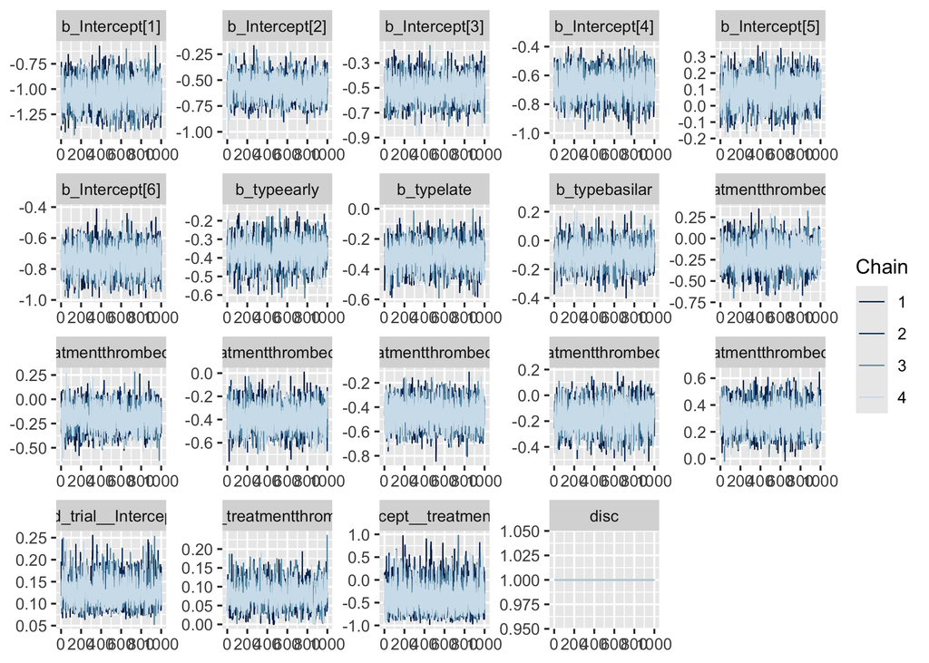

Figure 2: Trace plots for each parameter

There were no divergences during model fit. Figure 3 shows rhat values all less than 1.05.

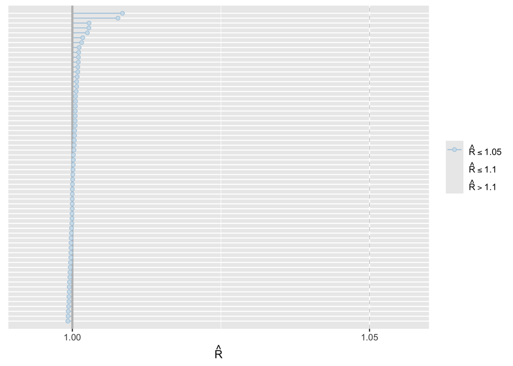

Figure 3: Rhat values for each parameter

Figure 4 shows that the estimated ratio of effective sample sizes to total sample sizes was greater than 0.1 for all parameters.

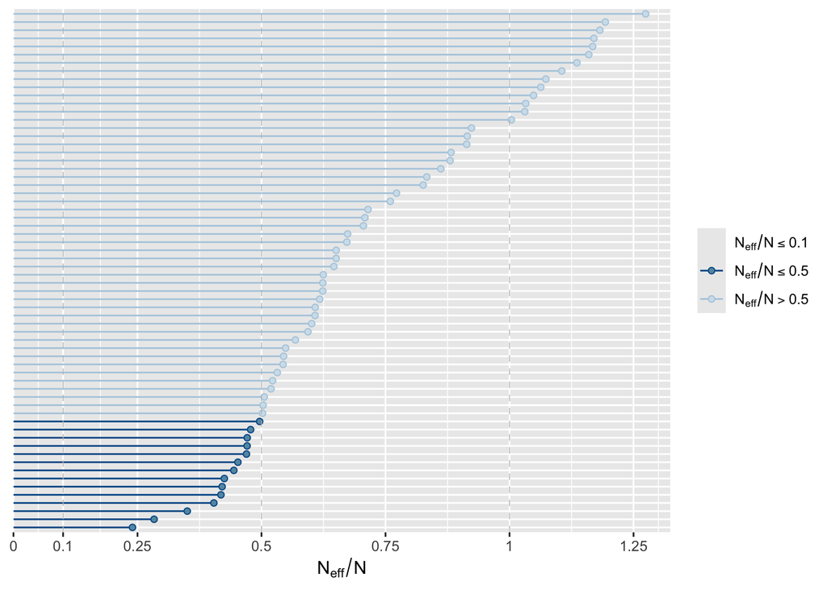

Figure 4: Estimated ratio of effective to total sample size for each parameter

## Model checks

In addition to verifying that there were no technical problems with the MCMC algorithm when fitting the model, we also need to check for evidence of over-fitting or under-fitting to the data.

Figure 5 is a graphical posterior predictive check of the model fit to the observed data. This can be thought of as the bayesian analogue of a chi-squared goodness-of-fit test. The posterior predictive distributions of the model (y<sub>rep</sub>) all include the observed values (y). There is no obvious evidence of misfit of model predictions to data.

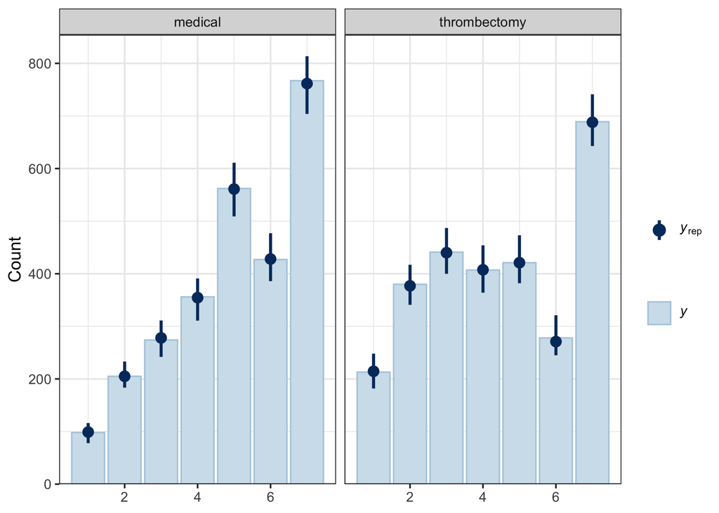

Figure 5: Graphical posterior predictive check

We can also check the predictive performance of the model using leave-one-out cross-validation.

```
Computed from 4000 by 5518 log-likelihood matrix

         Estimate   SE
elpd_loo  -9938.9 37.1
p_loo        42.0  0.6
looic     19877.8 74.1
------
Monte Carlo SE of elpd_loo is 0.1.

All Pareto k estimates are good (k < 0.5).
See help('pareto-k-diagnostic') for details.
```

# Results

## Ordinal treatment effect of thrombectomy across stroke types

The model considers a hypothetical patient enrolled in a new randomized trial of thrombectomy and uses the totality of observed data from previous trials to generate expected probabilities for each mRS at six months if the patient were enrolled in the medical arm of the trial, as well as the change in probability (either increase or decrease) if the patient was instead enrolled in the treatment arm of the trial. We refer to these changes as the ordinal treatment effect.

### Large stroke

Table 2 shows the expected ordinal probabilities for a hypothetical patient randomized to the medical treatment arm of a new large core stroke trial.

Table 2: Expected ordinal probabilities in medical arm of hypothetical new large stroke trial

| mRS | estimate mean | estimate low | estimate high |
| --- | --- | --- | --- |
| 0 | 1.3 | 0.7 | 2.1 |
| 1 | 3.6 | 2.3 | 5.1 |
| 2 | 6.3 | 4.6 | 8.3 |
| 3 | 10.5 | 8.4 | 12.5 |
| 4 | 20.5 | 18.4 | 22.3 |
| 5 | 18.7 | 16.9 | 20.5 |
| 6 | 39.1 | 33.3 | 45.5 |

Table 3 shows the expected ordinal treatment effect of thrombectomy in this trial.

Table 3: Expected ordinal treatment effect of thrombectomy in new large stroke trial. Positive numbers reflect an absolute increase in probability of the mRS category. Negative numbers reflect an absolute decrease.

| mRS | estimate mean | estimate low | estimate high |
| --- | --- | --- | --- |
| 0 | 2.1 | 1.2 | 3.3 |
| 1 | 4.3 | 2.8 | 6.1 |
| 2 | 5.2 | 3.6 | 7.0 |
| 3 | 2.6 | 0.9 | 4.3 |
| 4 | -4.3 | -6.6 | -1.9 |
| 5 | -6.2 | -8.4 | -4.1 |
| 6 | -3.6 | -7.5 | 0.2 |

### Small stroke, early window

Table 4 shows the expected ordinal probabilities for a hypothetical patient randomized to the medical treatment arm of a new small stroke early window trial.

Table 4: Expected ordinal probabilities in medical arm of hypothetical new small stroke early window trial

| mRS | estimate mean | estimate low | estimate high |
| --- | --- | --- | --- |
| 0 | 5.8 | 4.0 | 7.9 |
| 1 | 11.2 | 8.6 | 14.0 |
| 2 | 13.6 | 11.3 | 15.8 |
| 3 | 15.6 | 14.0 | 17.3 |
| 4 | 21.1 | 19.4 | 22.9 |
| 5 | 13.4 | 11.4 | 15.5 |
| 6 | 19.4 | 15.3 | 23.8 |

Table 5: Expected ordinal treatment effect of thrombectomy in new small stroke early window trial. Positive numbers reflect an absolute increase in probability of the mRS category. Negative numbers reflect an absolute decrease.

| mRS | estimate mean | estimate low | estimate high |
| --- | --- | --- | --- |
| 0 | 6.2 | 4.1 | 8.7 |
| 1 | 8.1 | 5.6 | 10.6 |
| 2 | 5.9 | 3.5 | 8.1 |
| 3 | -0.3 | -2.5 | 1.9 |
| 4 | -8.0 | -10.1 | -5.9 |
| 5 | -6.3 | -8.0 | -4.8 |
| 6 | -5.5 | -8.2 | -3.1 |

### Small stroke, late window

Table 6 shows the expected ordinal probabilities for a hypothetical patient randomized to the medical treatment arm of a new small stroke late window trial.

Table 6: Expected ordinal probabilities in medical arm of hypothetical new small stroke late window trial

| mRS | estimate mean | estimate low | estimate high |
| --- | --- | --- | --- |
| 0 | 4.6 | 2.7 | 7.4 |
| 1 | 9.5 | 6.5 | 13.3 |
| 2 | 12.3 | 9.4 | 15.3 |
| 3 | 14.9 | 12.9 | 16.9 |
| 4 | 21.5 | 19.7 | 23.3 |
| 5 | 14.6 | 11.9 | 17.1 |
| 6 | 22.6 | 16.2 | 29.0 |

Table 7 shows the expected ordinal treatment effect of thrombectomy in this trial.

Table 7: Expected ordinal treatment effect of thrombectomy in new small stroke late window trial. Positive numbers reflect an absolute increase in probability of the mRS category. Negative numbers reflect an absolute decrease.

| mRS | estimate mean | estimate low | estimate high |
| --- | --- | --- | --- |
| 0 | 5.4 | 3.4 | 8.0 |
| 1 | 7.6 | 5.2 | 10.1 |
| 2 | 6.1 | 3.9 | 8.3 |
| 3 | 0.4 | -2.1 | 2.7 |
| 4 | -7.5 | -9.8 | -5.1 |
| 5 | -6.5 | -8.3 | -4.8 |
| 6 | -5.6 | -8.5 | -2.8 |

### Basilar stroke

Table 8: Expected ordinal probabilities in medical arm of hypothetical new basilar stroke trial

| mRS | estimate mean | estimate low | estimate high |
| --- | --- | --- | --- |
| 0 | 2.0 | 1.1 | 3.4 |
| 1 | 5.1 | 3.2 | 7.5 |
| 2 | 8.1 | 5.8 | 10.8 |
| 3 | 12.1 | 9.8 | 14.4 |
| 4 | 21.4 | 19.5 | 23.2 |
| 5 | 17.7 | 15.5 | 19.8 |
| 6 | 33.5 | 26.6 | 40.8 |

Table 9 shows the expected ordinal treatment effect of thrombectomy in this trial.

Table 9: Expected ordinal treatment effect of thrombectomy in new basilar stroke trial. Positive numbers reflect an absolute increase in probability of the mRS category. Negative numbers reflect an absolute decrease.

| mRS | estimate mean | estimate low | estimate high |
| --- | --- | --- | --- |
| 0 | 3.1 | 1.8 | 4.8 |
| 1 | 5.5 | 3.6 | 7.6 |
| 2 | 5.8 | 4.0 | 7.7 |
| 3 | 2.2 | 0.3 | 4.1 |
| 4 | -5.4 | -7.9 | -2.8 |
| 5 | -6.5 | -8.5 | -4.5 |
| 6 | -4.7 | -8.3 | -0.9 |

### Summary

Conditional on the observed data and the model used to analyze the data, thrombectomy is expected to reliably lower the probability of bad outcomes and raise the probability of good outcomes across all stroke types. Figure 6 plots these estimates to show the trend graphically.

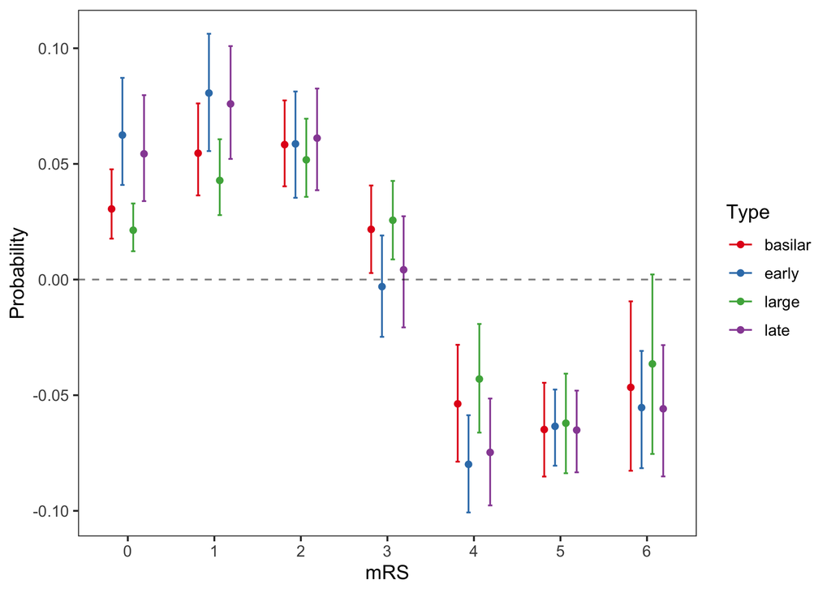

Figure 6: Expected ordinal treatment effect of thrombectomy in a hypothetical new trial

These treatment effects should be considered in the context of the expected probability of each outcome with medical treatment alone, as shown in Figure 7, which shows considerable variation by stroke type.

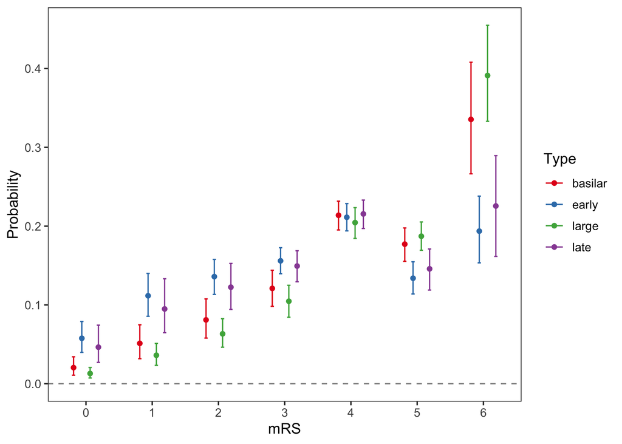

Figure 7: Expected ordinal probabilities in a new trial with medical treatment alone

## Comparison to relative ordinal treatment effect

Figure 8 shows the expected relative impact of thrombectomy on mRS in a new trial. Thrombectomy has a higher relative impact for large and basilar strokes because the base-rates of poor outcomes are high and the base-rates for good outcomes are low.

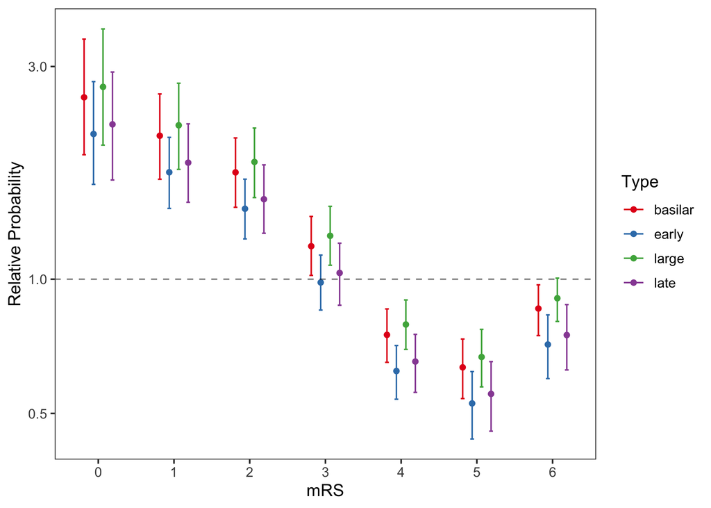

Figure 8: Expected relative impact of thrombectomy on mRS in new a trial

## Comparison to dichotomous treatment effect estimate

### Absolute dichotomous effect

Table 10 shows the implied dichotomous treatment effect estimate from this model.

Table 10: Effect of treatment on expected probability of mRS 0-2 in a hypothetical new trial

| type | estimate mean | estimate low | estimate high |
| --- | --- | --- | --- |
| large | 11.6 | 8.1 | 15.6 |
| early | 20.2 | 16.1 | 24.4 |
| late | 19.1 | 15.0 | 23.7 |
| basilar | 14.3 | 10.4 | 18.9 |

Figure 9 plots the estimates with the observed effect for comparison.

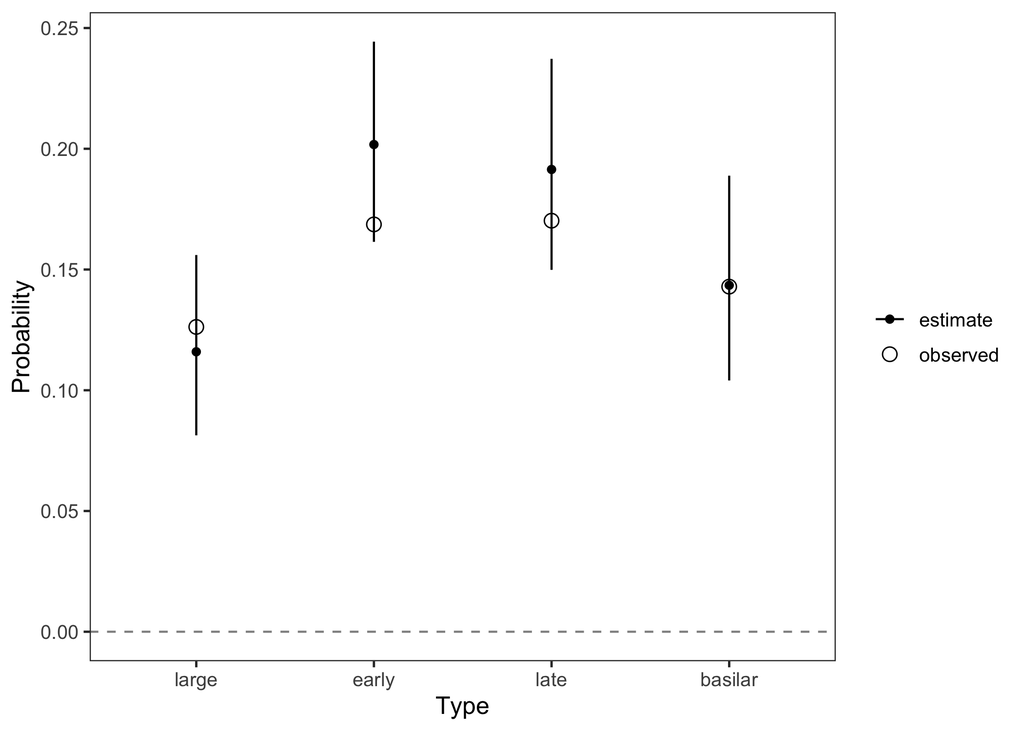

Figure 9: Effect of treatment on expected probability of mRS 0-2 in a hypothetical new trial. Mean observed effect plotted for comparison.

### Relative dichotomous effect

Table 11 shows this effect in relative terms.

Table 11: Relative effect of treatment on expected probability of mRS 0-2 in a hypothetical new trial

| type | estimate mean | estimate low | estimate high |
| --- | --- | --- | --- |
| large | 2.0 | 1.7 | 2.4 |
| early | 1.7 | 1.5 | 1.9 |
| late | 1.7 | 1.5 | 2.0 |
| basilar | 2.0 | 1.7 | 2.3 |

Figure 10 plots the estimates with the observed effect for comparison.

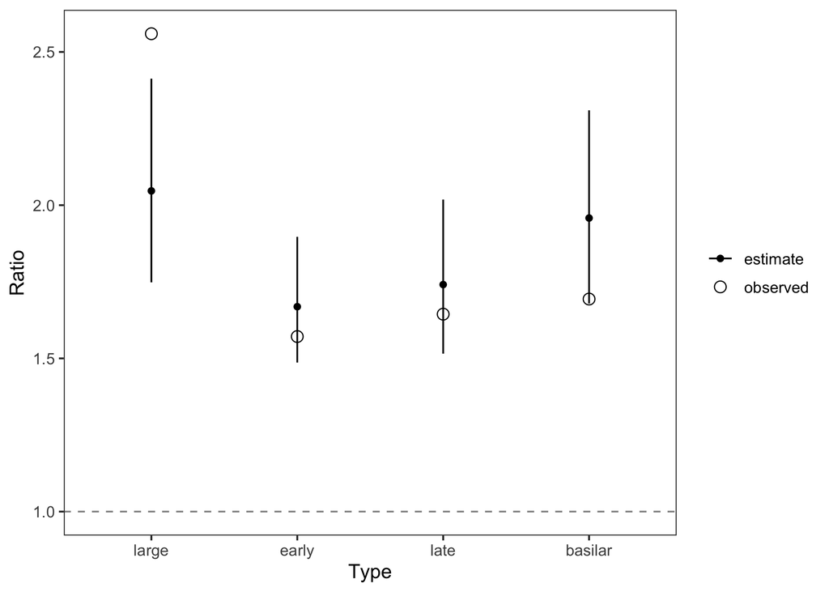

Figure 10: Relative effect of treatment on expected probability of mRS 0-2 in a hypothetical new trial. Mean observed effect plotted for comparison.

# Sensitivity Analyses

## Sensitivity to prior specification

With flat priors, there is no difference in out-of-sample performance.

```
         elpd_diff se_diff
omr_ip    0.0       0.0
omr_flat -0.4       0.1
```

Figure 11 shows treatment effect estimate under flat prior assumption, which can be compared to Figure 6, the estimates under the main model specification.

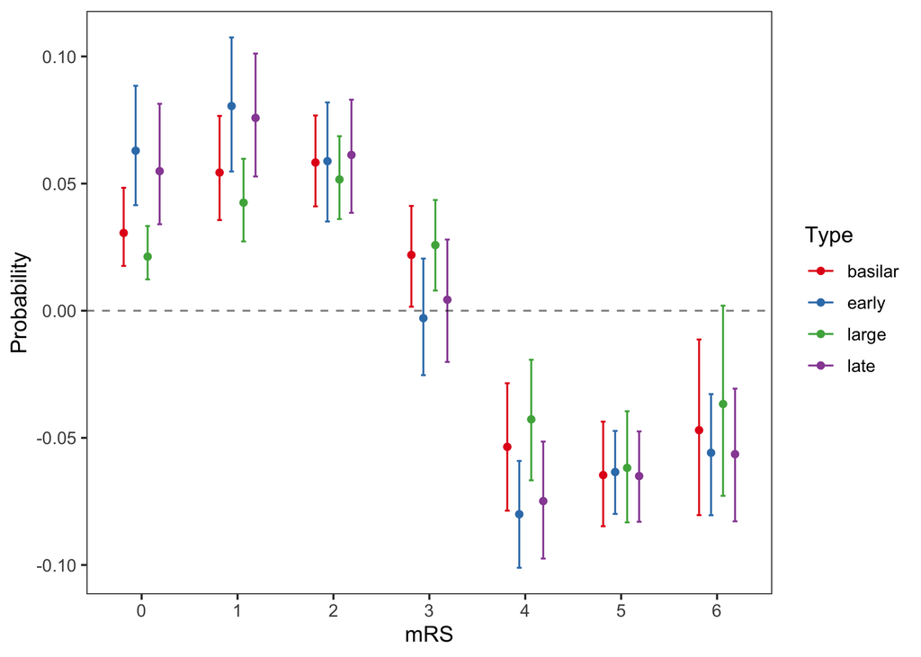

Figure 11: Expected impact of thrombectomy on mRS in new a trial, flat priors

The results are virtually identical. Conclusion: reported results are relatively insensitive to prior choice.

## Sensitivity to adjacent category parameterization

The main model assumes the adjacent category paramerization of ordinal regression, which allows for the modelling of category specific effects. An alternative parameterization of ordinal regression, referred to as cumulative ordinal regression, makes the proportional odds assumption.

```
        elpd_diff se_diff
omr_ip    0.0       0.0
omr_cum -35.8       9.0
```

In addition to making the questionable assumption that the treatment effect of thrombectomy is constant across all mRS categories, this model also results in worse out-of-sample performance.

## Sensitivity to meta-regression

Dropping predictors for stroke type does not result in decreased out-of-sample predictive performance.

```
       elpd_diff se_diff
omr_ip  0.0       0.0
oma    -0.4       1.2
```

This implies that the ordinal treatment effect of thrombectomy is relatively consistent across stroke types, at least for this data set.